# mathanalysis_standardcalc1

```python
%%html
<style>
@import url('https://fonts.googleapis.com/css?family=Roboto&effect=3d|brick-sign|');
span {font-family:Roboto; color:black; text-shadow:4px 4px 4px #aaa;}
h1,h2 {font-family:Roboto; color:slategray; text-shadow:4px 4px 4px #aaa;}
div.output_subarea, div.output_area pre{font-family:Roboto; font_size:120%; color:darkblue;}
</style>
```

```python
import math, sympy, numpy
sympy.init_printing(use_unicode=True)
from sympy import *
import pylab as plt
%matplotlib inline
```

[GeoGebra](https://www.geogebra.org/graphing?lang=en)

LaTeX/Mathematics

[SymPy Tutorial. Calculus](https://docs.sympy.org/latest/tutorial/calculus.html)

[SymPy Modules Reference. Calculus](https://docs.sympy.org/latest/modules/calculus/index.html)

# Вариант 22

## Типовой расчет №1

Доказать, что $\large{\displaystyle{\lim_{n \to \infty} \frac { 5n }{8n + 3} = \frac{5}{8} }}$

Решение.

По определению, предел последовательности $\large{\displaystyle{ a_n = \frac{5n}{8n + 3} }}$ при $n \to \infty$ равен $\large{\frac{5}{8}}$, если

для любого $\varepsilon > 0$ существует такой номер $N(\varepsilon)$, что для всех номеров $n > N$ выполняется неравенство

$ \large{\displaystyle{\bigg| \frac{5n}{8n + 3} - \frac{5}{8} \bigg| < \varepsilon }}$ (1), т.е.

$ \large{\displaystyle{\forall \varepsilon > 0 \ \exists N = N(\varepsilon) \in \mathbb{N}: \forall n > N \implies \bigg| \frac{5n}{8n + 3} - \frac{5}{8}}} \bigg| < \varepsilon$.

Зафиксируем произвольное $\varepsilon > 0$ и найдем номер $N(\varepsilon)$, для которого выполняется неравенство (1).

$ \large{\displaystyle{\bigg| \frac{5n}{8n + 3} - \frac{5}{8} \bigg| = \bigg| \frac{40n - 40n -15}{8 * (8n + 3)} \bigg| = \bigg| \frac{ -15}{64n + 24} \bigg| = \bigg| \frac{ 15}{64n + 24} \bigg| = \frac{ 15}{64n + 24} }}$, т.к. $n \in \mathbb{N}$.

Неравенство (1) примет вид:

$ \large{\displaystyle{\frac{ 15}{64n + 24} < \varepsilon \iff 64n + 24 > \frac{15}{\varepsilon} \iff n > \frac{15}{64\varepsilon} - \frac{3}{8} \iff n > \frac{15 - 24\varepsilon}{64\varepsilon} (2) }}$

Для выполнения неравенства (1) достаточно подобрать такое $N = N(\varepsilon) \in \mathbb{N}$, что (2) будет выполнено для всех $n > N$.

Функция $\large{\displaystyle{\frac{15 -24\varepsilon}{64\varepsilon} }}$ определена для любого $\varepsilon > 0$,

следовательно $N = N(\varepsilon) \in \mathbb{N}$, при которых будет выполнено (2) для всех $n > N$, можно найти всегда.

Например, при

$\large{\displaystyle{\varepsilon = \frac {15}{88} : n > \frac{15 * 88 - 24 * 15}{64 * 15} }}\iff n > 1 \implies N = 1$;

$\large{\displaystyle{\varepsilon = 0.125 : n > \frac{15 - 24 * 0.125}{64 * 0.125} }}\iff n > 1.5 \implies N = 2$ и т.д.

В качестве $N = N(\varepsilon) \in \mathbb{N}$ можно взять любое натуральное число, превышающее $\large{\displaystyle{\frac{15 -24\varepsilon}{64\varepsilon} : n > N > \frac{15 -24\varepsilon}{64\varepsilon} }}$ .

Таким образом, $ \large{\displaystyle{N = \begin {cases} 1 , \varepsilon \geq \frac{15}{88} \\ \bigg[ \frac{15 -24\varepsilon}{64\varepsilon} \bigg] + 1, \varepsilon < \frac{15}{88} \end{cases} }}$.

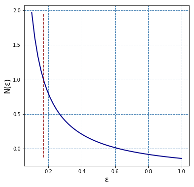

```python
def N(e): return (15 - 24 * e) / (64 * e)
f = plt.figure(figsize=(6,6))
ax = f.add_subplot(111)
ax.grid(c='steelblue', ls='--', lw=1)
e = numpy.linspace(0.1,1)
n = [N(el) for el in e]
ax.plot(e, n, c='darkblue', lw=2)
ax.axvline(15/88, 0.05, 0.95, c='darkred',ls='--')
plt.xlabel('ε', fontsize=15); plt.ylabel('N(ε)', fontsize=15);
```

```python
n = symbols('n')
limit( 5 * n / (8 * n + 3), n, oo)
```

$$\frac{5}{8}$$

## Типовой расчет №2

Вычислить предел последовательности $\large{\displaystyle{\lim_{n \to \infty} \frac{n^2 \sqrt[5]{13n + 1} + \sqrt{81n^6 -13} }{(2n - 5 \sqrt[3]{n}) \sqrt{4n^4 + 7n + 8}} }}$

Решение.

Числитель и знаменатель дроби являются бесконечно большими последовательностями,

значит при вычислении предела имеется неопределенность вида $\large{[\frac {\infty}{\infty}]}$.

Для ее раскрытия преобразуем формулу общего члена исходной последовательности.

Заметим, что $\large{n^2 \sqrt[5]{13n + 1} + \sqrt{81n^6 -13} \sim n^2 \sqrt[5]{13n} + \sqrt{81n^6} \sim n^2 \sqrt[5]{n} + \sqrt{n^6} \sim n^3} $ при $n \to \infty$.

Числитель исходной последовательности подобен $n^3$, поэтому разделим и числитель, и знаменатель на $n^3$.

$\large{\displaystyle{a_n = \frac{(n^2 \sqrt[5]{13n + 1} + \sqrt{81n^6 -13} ) / n^3 }{(2n - 5 \sqrt[3]{n}) \sqrt{4n^4 + 7n + 8} / n^3} = }}$

$\large{\displaystyle{= \frac{\sqrt[5]{\frac{13}{n^4} + \frac{1}{n^5}} + \sqrt{81 - \frac{13}{n^6}} }{(2 - \frac{5}{\sqrt[3]{n^2}}) \sqrt{4 + \frac{7}{n^3} + \frac{8}{n^4}}} }}$

Последовательности $\large{\displaystyle{ \left\{ \frac{13}{n^4} \right\} , \left\{ \frac{1}{n^5} \right\}, ...}}$ являются бесконечно малыми при $n \to \infty$.

Применяя арифметические свойства пределов последовательности, получим:

$\large{\displaystyle{\lim_{n \to \infty} \frac{\sqrt[5]{\frac{13}{n^4} + \frac{1}{n^5}} + \sqrt{81 - \frac{13}{n^6}} }{(2 - \frac{5}{\sqrt[3]{n^2}}) \sqrt{4 + \frac{7}{n^3} + \frac{8}{n^4}}} }} = \frac{\sqrt{81}}{2 * \sqrt{4}} = 2.25$

```python
n = symbols('n')
limit((n**2*(13*n + 1)**0.2 + (81*n**6 - 13)**0.5)/((2*n - 5*n**(1/3))*(4*n**4 + 7*n + 8)**0.5), n, oo)
```

$$2.25$$

## Типовой расчет №3

Вычислить предел последовательности $\large{\displaystyle{\lim_{n \to \infty} \sqrt{n^5} (\sqrt{6 + n^5} - \sqrt{4 + n ^5}) }}$

Решение.

$\large{\displaystyle{ \sqrt{n^5}\sqrt{6 + n^5} , \sqrt{n^5}\sqrt{4 + n ^5} \sim \sqrt{n^5} \sqrt{n ^5}}} \sim n^5 $ при $n \to \infty$.

Значит, требуется раскрыть необределенность вида $[\infty - \infty]$.

Применим умножение на сопряженное выражение.

$\large{\displaystyle{ \sqrt{n^5} (\sqrt{6 + n^5} - \sqrt{4 + n ^5}) = \frac{\sqrt{n^5} (\sqrt{6 + n^5} - \sqrt{4 + n ^5})(\sqrt{6 + n^5} + \sqrt{4 + n ^5})}{\sqrt{6 + n^5} + \sqrt{4 + n ^5}} = }}$

$\large{\displaystyle{ = \frac{\sqrt{n^5} (6 + n^5 - 4 - n ^5)}{\sqrt{6 + n^5} + \sqrt{4 + n ^5}} = \frac{2\sqrt{n^5}}{\sqrt{6 + n^5} + \sqrt{4 + n ^5}} = }}$

$\large{\displaystyle{ = \frac{ 2 \sqrt{n^5} \sqrt{n^{-5}} }{ \sqrt{n^{-5}} (\sqrt{6 + n^5} + \sqrt{4 + n ^5}) } = \frac{ 2 }{ \sqrt{n^{-5}} (\sqrt{6 + n^5} + \sqrt{4 + n ^5}) } = }} $

$\large{\displaystyle{ = \frac{ 2 }{ \sqrt{\frac{6}{n^5} + 1} + \sqrt{\frac{4}{n^5} + 1} } }} $

Последовательности $\large{\displaystyle{ \left\{ \frac{6}{n^5} \right\} , \left\{ \frac{4}{n^5} \right\} }}$ являются бесконечно малыми при $n \to \infty$.

Применяя арифметические свойства пределов последовательности, получим:

$\large{\displaystyle{\lim_{n \to \infty} \frac{2}{\sqrt{\frac{6}{n^5} + 1} + \sqrt{\frac{4}{n^5} + 1}} = \frac{2}{1 + 1} = 1}}$

```python
n = symbols('n')
limit(n ** 2.5 * ((6 + n ** 5) ** 0.5 - (4 + n ** 5) ** 0.5), n, oo)
```

$$1.0$$

## Типовой расчет №4

Вычислить предел последовательности $\large{\displaystyle{\lim_{n \to \infty} \frac{4 + 8 + 12 + ... + 4n}{\sqrt[3]{n^2 + 5} + \sqrt{4n^4 + 6}} }}$

Решение.

Применим формулу суммы арифметической прогрессии и преобразуем числитель дроби:

$\large{\displaystyle{\frac{4 + 8 + 12 + ... + 4n}{\sqrt[3]{n^2 + 5} + \sqrt{4n^4 + 6}} = \frac{(2 * 4 + 4 *(n - 1)) * n / 2 }{\sqrt[3]{n^2 + 5} + \sqrt{4n^4 + 6}} = \frac{2 n^2 + 2n }{\sqrt[3]{n^2 + 5} + \sqrt{4n^4 + 6}} }}$

Числитель и знаменатель дроби являются бесконечно большими последовательностями.

При вычислении предела раскроем неопределенность вида $\large{[\frac {\infty}{\infty}]}$.

Числитель подобен $n^2$ при $n \to \infty$, значит необходимо поделить и числитель, и знаменатель на $n^2$.

$\large{\displaystyle{\frac{(2 n^2 + 2n) / n^2}{\bigg(\sqrt[3]{n^2 + 5} + \sqrt{4n^4 + 6}\bigg) / n^2} = \frac{2 + \frac{2}{n}}{\sqrt[3]{\frac{1}{n^4} + \frac{5}{n^6}} + \sqrt{4 + \frac{6}{n^4}}} }}$.

Последовательности $\large{\displaystyle{ \left\{ \frac{2}{n} \right\} , \left\{ \frac{1}{n^4} \right\}, ...}}$ являются бесконечно малыми при $n \to \infty$.

Применяя арифметические свойства пределов последовательности, получим:

$\large{\displaystyle{\lim_{n \to \infty} \frac{2 + \frac{2}{n}}{\sqrt[3]{\frac{1}{n^4} + \frac{5}{n^6}} + \sqrt{4 + \frac{6}{n^4}}} = \frac {2 + 0} {\sqrt[3]{0 + 0} + \sqrt{4 + 0}} = 1}}$.

```python
n = symbols('n')
limit((2 * n ** 2 + 2 * n) / ((n ** 2 + 5 ) ** (1/3) + (4 * n ** 4 + 6) ** 0.5), n, oo)
```

$$1.0$$

## Типовой расчет №5

Вычислить предел последовательности $\large{\displaystyle{\lim_{n \to \infty} \Bigg( \frac{n^2 + 4n - 3}{n^2 - n + 6} \Bigg)^{3n} }}$.

Решение.

1) Докажем, что $\large{\displaystyle{\lim_{n \to \infty} \frac{n^2 + 4n - 3}{n^2 - n + 6} = 1}}$.

Числитель и знаменатель дроби являются бесконечно большими последовательностями.

При вычислении предела необходимо раскрыть неопределенность вида $\large{[\frac {\infty}{\infty}]}$.

Числитель подобен $n^2$ при $n \to \infty$, значит нужно поделить и числитель, и знаменатель на $n^2$.

$\large{\displaystyle{ \frac{n^2 + 4n - 3}{n^2 - n + 6} = \frac{(n^2 + 4n - 3) / n^2}{(n^2 - n + 6) / n^2} = \frac{1 + \frac{4}{n} - \frac{3}{n^2}}{1 - \frac{1}{n} + \frac{6}{ n^2}} }}$

Последовательности $\large{\displaystyle{ \left\{ \frac{4}{n} \right\} , \left\{ \frac{-3}{n^2} \right\}, ...}}$ являются бесконечно малыми при $n \to \infty$.

$\large{\displaystyle{\lim_{n \to \infty} \frac{n^2 + 4n - 3}{n^2 - n + 6} = \frac {1 + 0 - 0}{1 - 0 + 0} = 1}}$

2) $\large{\displaystyle{3n \to \infty}}$ при $\large{\displaystyle{n \to \infty}}$.

Значит, исходная последовательность под знаком предела является неопределенным выражением вида $\large{\displaystyle{1^{\infty} }}$.

Воспользуемся формулой второго замечательного предела:

### $\large{\displaystyle{\lim_{n \to \infty} \Bigg( 1 + \alpha_n \Bigg) ^ {\frac{1}{\alpha_n}} = e }}$,

где $\large{\displaystyle{ \{ \alpha_n \} }}$ - бесконечно малая последовательность.

$\large{\displaystyle{\Bigg( \frac{n^2 + 4n - 3}{n^2 - n + 6} \Bigg)^{3n} = \Bigg( 1 + \frac{5n - 9}{n^2 - n + 6} \Bigg)^{3n} = \Bigg[ \bigg( 1 + \frac{5n - 9}{n^2 - n + 6} \bigg)^ \frac{n^2 - n + 6}{5n - 9} \Bigg] ^ {\frac{3n * (5n - 9)}{n^2 - n + 6}} }}$.

Последовательность $\large{\displaystyle{\left\{ \alpha_n = \frac{5n - 9}{n^2 - n + 6} \right\} }}$ является бесконечно малой при $\large{\displaystyle{n \to \infty}}$.

$\large{\displaystyle{\lim_{n \to \infty} \bigg( 1 + \frac{5n - 9}{n^2 - n + 6} \bigg) ^ \frac{n^2 - n + 6}{5n - 9} = e }}$.

3) Вычислим $\large{\displaystyle{\lim_{n \to \infty} \frac{3n * (5n - 9)}{n^2 - n + 6} }}$.

$\large{\displaystyle{\frac{3n * (5n - 9)}{n^2 - n + 6} = \frac{15n^2 - 27n}{n^2 - n + 6} = \frac{(15n^2 - 27n) / n^2}{(n^2 - n + 6) / n^2} = \frac{15 - \frac{27}{n} }{1 - \frac{1}{n} + \frac{6}{ n^2} } }}$

$\large{\displaystyle{\lim_{n \to \infty} \frac{15 - \frac{27}{n} }{1 - \frac{1}{n} + \frac{6}{ n^2} } = \frac{15 - 0}{1 - 0 + 0} = 15 \implies }}$

$\large{\displaystyle{\lim_{n \to \infty} \Bigg[ \bigg( 1 + \frac{5n - 9}{n^2 - n + 6} \bigg)^ \frac{n^2 - n + 6}{5n - 9} \Bigg] ^ {\frac{3n * (5n - 9)}{n^2 - n + 6}} = e^{15} \approx 3 \ 269 \ 017}}$.

```python
n = symbols('n')
limit(((n ** 2 + 4 * n - 3) / (n ** 2 - n + 6) ) ** (3 * n), n, oo)
```

$$e^{15}$$

```python
math.e ** 15
```

$$3269017.372472108$$

## Типовой расчет №6

Используя определение предела функции по Коши, доказать равенство ( найти $\delta (\varepsilon) $ ):

$\large{\displaystyle{\lim_{x \to 3} ( -2x^2 - 4 ) = -22 }}$.

Решение.

Запишем определение по Коши для данного случая.

Число $-22$ является пределом функции $f(x) = -2x^2 - 4$ при $x \to 3$, если

для любого $\varepsilon > 0$ существует такое число $\delta(\varepsilon) > 0$,

что для всех $x$, удовлетворяющих условию $0 < |x - 3| < \delta \ (1)$

выполняется неравенство $|(-2x^2 - 4) - (-22) | < \varepsilon \iff |-2x^2 + 18 | < \varepsilon \ (2)$, т.е.

$ \large{\displaystyle{\forall \varepsilon > 0 \ \exists \delta = \delta(\varepsilon) >0: \{ \forall x: 0 < \mid x - 3 \mid < \delta \implies \mid -2x^2 + 18 \mid < \varepsilon \} }}$.

Зафиксируем произвольное число $\varepsilon > 0$ и найдем такое $\delta(\varepsilon) > 0$,

что для всех $x$, удовлетворяющих условию (1), выполнялось неравенство (2).

*I способ.*

$\large{\displaystyle{ 0 < |x - 3| < \delta \iff -\delta < x - 3 < \delta, x \neq 3 \ (1*) }}$

$\large{\displaystyle{|-2x^2 + 18 | < \varepsilon \iff |x^2 - 9 | < \frac{\varepsilon}{2} \iff 9 - \frac{\varepsilon}{2} < x ^2 < 9 + \frac{\varepsilon}{2} \iff}}$

$\large{\displaystyle{ \iff \begin {cases} \sqrt{9 - \frac{\varepsilon}{2}} < x < \sqrt{9 + \frac{\varepsilon}{2}}, \forall \varepsilon \leq 18 \\ -\sqrt{9 + \frac{\varepsilon}{2}} < x < \sqrt{9 + \frac{\varepsilon}{2}}, \forall \varepsilon > 18 \end{cases} \iff }}$

$\large{\displaystyle{ \iff \begin {cases} \sqrt{9 - \frac{\varepsilon}{2}} - 3 < x - 3 < \sqrt{9 + \frac{\varepsilon}{2}} - 3, \forall \varepsilon \leq 18 \\ -\sqrt{9 + \frac{\varepsilon}{2}} - 3 < x - 3 < \sqrt{9 + \frac{\varepsilon}{2}} - 3, \forall \varepsilon > 18 \end{cases} \iff }}$

$\large{\displaystyle{ \iff \begin {cases} -(3 - \sqrt{9 - \frac{\varepsilon}{2}}) < x - 3 < \sqrt{9 + \frac{\varepsilon}{2}} - 3, \forall \varepsilon \leq 18 \\ -(\sqrt{9 + \frac{\varepsilon}{2}} + 3) < x - 3 < \sqrt{9 + \frac{\varepsilon}{2}} - 3, \forall \varepsilon > 18 \end{cases} \ (2*) }}$

При $0 < \varepsilon \leq 18$ выберем $\delta =\min \{ 3 - \sqrt{9 - \frac{\varepsilon}{2}}, \sqrt{9 + \frac{\varepsilon}{2}} - 3 \}$.

Сравним эти числа.

$\large{\displaystyle{ \frac{ 3 - \sqrt{9 - \frac{\varepsilon}{2}} } {\sqrt{9 + \frac{\varepsilon}{2}} - 3} = }} $

$ \large{\displaystyle{= \frac{ 3 - \sqrt{9 - \frac{\varepsilon}{2}} } {\sqrt{9 + \frac{\varepsilon}{2}} - 3} * \frac{3 + \sqrt{9 - \frac{\varepsilon}{2}}} {3 + \sqrt{9 - \frac{\varepsilon}{2}}} * \frac{\sqrt{9 + \frac{\varepsilon}{2}} + 3} {\sqrt{9 + \frac{\varepsilon}{2}} + 3} = }}$

$\large{\displaystyle{ = \frac{\sqrt{9 + \frac{\varepsilon}{2}} + 3} {3 + \sqrt{9 - \frac{\varepsilon}{2}}} * \frac{\varepsilon}{2} * \frac{2}{\varepsilon} = }} $

$\large{\displaystyle{ = \frac{\sqrt{9 + \frac{\varepsilon}{2}} + 3} {\sqrt{9 - \frac{\varepsilon}{2}} + 3} > 1 \implies }} $

$\delta =\sqrt{9 + \frac{\varepsilon}{2}} - 3, \forall \varepsilon: 0 < \varepsilon \leq 18$.

При $\varepsilon > 18$ выберем $\delta =\min \{ \sqrt{9 + \frac{\varepsilon}{2}} + 3, \sqrt{9 + \frac{\varepsilon}{2}} - 3 \} = \sqrt{9 + \frac{\varepsilon}{2}} - 3$.

Выражение полностью идентично предыдущему случаю $\implies \delta = \sqrt{9 + \frac{\varepsilon}{2}} - 3, \forall \varepsilon > 0$.

*II способ.*

$\large{\displaystyle{ 0 < |x - 3| < \delta \ (1*) }}$.

$\large{\displaystyle{| -2x^2 + 18 | = 2 * | x^2 - 9 | = 2 * |x - 3| * |x + 3| = 2 * |x - 3| * |x - 3 + 6| \ (2*) }}$.

$\large{\displaystyle{ (1*), (2*) \implies | -2x^2 + 18 | < 2 * \delta * (\delta + 6) = 2\delta^2 + 12\delta}}$.

Неравенство $(2)$ выполняется при $2\delta^2 + 12\delta \leq \varepsilon$.

Решим это неравенство при фиксированном $\varepsilon > 0$ относительно $\delta > 0$:

$2\delta^2 + 12\delta \leq \varepsilon \iff \delta ^2 + 6\delta - \frac{\varepsilon}{2} \leq 0$

$D = 6^2 - 4 * (- \frac{\varepsilon}{2}) = 36 + 2\varepsilon$

$\implies \delta = \sqrt{9 + \frac{\varepsilon}{2}} - 3, \forall \varepsilon > 0$.

```python
x = symbols('x')
limit(-2 * x ** 2 - 4, x, 3)
```

$$-22$$

## Типовой расчет №7

Вычислить предел функции

$\large{\displaystyle{\lim_{x \to -1} \frac{x^3 + 5 x^2 + 8 x + 4}{x^3 + 7 x^2 + 16 x + 10} }}$.

Решение.

Числитель и знаменатель дроби стремятся к 0 при $x \to -1$,

значит дробь является неопределенным выражением вида $\big[\frac{0}{0}\big]$ при $x \to -1$.

Для раскрытия неопределенности разложим числитель и знаменатель на множители и

выполним тождественные преобразования при условии $x \neq -1$:

$\large{\displaystyle{ \frac{x^3 + 5 x^2 + 8 x + 4}{x^3 + 7 x^2 + 16 x + 10} = \frac{x^2 * (x + 1) + 4 x^2 + 8 x + 4}{x^2 * (x + 1) + 6 x^2 + 16 x + 10} = }}$

$\large{\displaystyle{= \frac{x^2 * (x + 1) + 4 x * (x + 1) + 4 * (x + 1)}{x^2 * (x + 1) + 6 x * (x + 1) + 10 * (x + 1)} = \frac{(x + 1) * (x^2 + 4 x + 4) }{(x + 1) * (x^2 + 6 x + 10)} = }}$

$\large{\displaystyle{ = \frac{ x^2 + 4 x + 4}{x^2 + 6 x + 10} }}$.

Используя арифметические свойства пределов функций, получим:

$\large{\displaystyle{ \lim_{x \to -1} \frac{ x^2 + 4 x + 4}{x^2 + 6 x + 10} = \frac{(-1)^2 + 4 * (-1) + 4}{(-1)^2 + 6 * (-1) + 10} = 0.2}}$.

```python
x = symbols('x')
limit((x ** 3 + 5 * x ** 2 + 8 * x + 4) / (x ** 3 + 7 * x ** 2 + 16 * x + 10), x, -1)
```

$$\frac{1}{5}$$

## Типовой расчет №8

Вычислить предел функции

$\large{\displaystyle{\lim_{x \to 0} \frac{\sqrt{2 + x} - \sqrt{2 - x}}{\sqrt[3]{2 + x} - \sqrt[3]{2 - x}} }}$.

Решение.

Числитель и знаменатель дроби стремятся к 0 при $x \to 0$,

значит дробь является неопределенным выражением вида $\big[\frac{0}{0}\big]$ при $x \to 0$.

Для раскрытия неопределенности

- домножим числитель и знаменатель дроби на выражения, соответствующие формулам разности квадратов и кубов,
- и выполним тождественные преобразования при условии $x \neq 0$:

$\large{\displaystyle{ \frac{\sqrt{2 + x} - \sqrt{2 - x}}{\sqrt[3]{2 + x} - \sqrt[3]{2 - x}} = \frac{(\sqrt{2 + x} - \sqrt{2 - x}) * (\sqrt{2 + x} + \sqrt{2 - x})} {(\sqrt[3]{2 + x} - \sqrt[3]{2 - x}) * (\sqrt{2 + x} + \sqrt{2 - x})} = }}$

$\large{\displaystyle{ \frac{2x}{(\sqrt[3]{2 + x} - \sqrt[3]{2 - x}) * (\sqrt{2 + x} + \sqrt{2 - x})} = }}$

$\large{\displaystyle{ \frac{2x * (\sqrt[3]{(2 + x)^2} + \sqrt[3]{4 - x^2} + \sqrt[3]{(2 - x)^2})}{(\sqrt[3]{2 + x} - \sqrt[3]{2 - x}) * (\sqrt[3]{(2 + x)^2} + \sqrt[3]{4 - x^2} + \sqrt[3]{(2 - x)^2}) * (\sqrt{2 + x} + \sqrt{2 - x})} = }}$

$\large{\displaystyle{ \frac{2x * (\sqrt[3]{(2 + x)^2} + \sqrt[3]{4 - x^2} + \sqrt[3]{(2 - x)^2})}{2x * (\sqrt{2 + x} + \sqrt{2 - x})} = \frac{\sqrt[3]{(2 + x)^2} + \sqrt[3]{4 - x^2} + \sqrt[3]{(2 - x)^2}} {\sqrt{2 + x} + \sqrt{2 - x}} }}$

$\large{\displaystyle{ \lim_{x \to 0} \frac{\sqrt[3]{(2 + x)^2} + \sqrt[3]{4 - x^2} + \sqrt[3]{(2 - x)^2}} {\sqrt{2 + x} + \sqrt{2 - x}} = \frac{\sqrt[3]{(2 + 0)^2} + \sqrt[3]{4 - 0} + \sqrt[3]{(2 - 0)^2}} {\sqrt{2 + 0} + \sqrt{2 - 0}} = }}$

$\large{\displaystyle{= \frac{3 * 2^{\frac{2}{3}}} {2^{\frac{3}{2}}} = 3 * 2^{\frac{2}{3} - \frac{3}{2}} = \frac {3}{\sqrt[6]{32}} }}$

```python
x = symbols('x')
limit(((2 + x) ** 0.5 - (2 - x) ** 0.5) / ((2 + x) ** (1/3) - (2 - x) ** (1/3)), x, 0)
```

$$1.68369307246406$$

```python
3 * 32 ** (-1/6)
```

$$1.6836930724640595$$

## Типовой расчет №9

Вычислить предел функции

$\large{\displaystyle{\lim_{x \to 0} \frac{sin^2{x} - tg^2{x}} {x^4} }}$.

Решение.

Числитель и знаменатель дроби стремятся к 0 при $x \to 0$,

значит дробь является неопределенным выражением вида $\big[\frac{0}{0}\big]$ при $x \to 0$.

Для раскрытия неопределенности преобразуем функцию, используя тригонометрические формулы:

$\large{\displaystyle{ \frac{sin^2{x} - tg^2{x}} {x^4} = \frac{sin^2{x} - \frac{sin^2{x}}{cos^2{x}}} {x^2 * x^2} = \frac{sin^2{x}} {x^2} * \frac{1 - \frac{1}{cos^2{x}}} {x^2} = }}$

$\large{\displaystyle{= - \frac{sin^2{x}} {x^2} * \frac{1 - cos^2{x}}{cos^2{x} * x^2} = - \frac{sin^2{x}} {x^2} * \frac{sin^2{x}}{cos^2{x} * x^2} = - \frac{sin^2{x}} {x^2} * \frac{tg^2{x}}{x^2} }}$.

Используем арифметические свойства пределов функций,

а также формулы первого замечательного предела и его следствий:

$\large{\displaystyle{\lim_{x \to 0}( - \frac{sin^2{x}} {x^2} * \frac{tg^2{x}}{x^2}) = - \lim_{x \to 0}\frac{sin^2{x}} {x^2} * \lim_{x \to 0} \frac{tg^2{x}}{x^2} = }}$

$\large{\displaystyle{= - \Big(\lim_{x \to 0} \frac{sin{x}} {x}\Big)^2 * \Big(\lim_{x \to 0} \frac{tg{x}} {x}\Big)^2 = - 1^2 * 1^2 = -1}}$

```python
x = symbols('x')
limit(((sin(x)) ** 2 - (tan(x)) ** 2) / (x ** 4), x, 0)
```

$$-1$$

## Типовой расчет №10